# R Notebook

## Setup

Setting up the current working directory and importing data from CSV, both train and test set Check the structure of data to see how many and what type of fields form the dataset

```r
setwd("C://Users//conne//Documents//Data Science//Profile//Git//R Projects//Housing Prediction")
getwd()
```

```
[1] "C:/Users/conne/Documents/Data Science/Profile/Git/R Projects/Housing Prediction"
```

```r
# read in OrderBreakdown.txt file into R as a data.frame named "data"
train <- read.table(file="train.csv", header=T, sep=",")
test <- read.table(file="test.csv", header=T, sep=",")
```

```r
#head(train,5)
#names(train)
str(train)
```

```
'data.frame':   1460 obs. of  82 variables:
 $ X            : int  1 2 3 4 5 6 7 8 9 10 ...
 $ Id           : int  1 2 3 4 5 6 7 8 9 10 ...
 $ MSSubClass   : int  60 20 60 70 60 50 20 60 50 190 ...
 $ MSZoning     : Factor w/ 5 levels "C (all)","FV",..: 4 4 4 4 4 4 4 4 5 4 ...
 $ LotFrontage  : int  65 80 68 60 84 85 75 NA 51 50 ...
 $ LotArea      : int  8450 9600 11250 9550 14260 14115 10084 10382 6120 7420 ...
 $ Street       : Factor w/ 2 levels "Grvl","Pave": 2 2 2 2 2 2 2 2 2 2 ...
 $ Alley        : Factor w/ 2 levels "Grvl","Pave": NA NA NA NA NA NA NA NA NA NA ...
 $ LotShape     : Factor w/ 4 levels "IR1","IR2","IR3",..: 4 4 1 1 1 1 4 1 4 4 ...
 $ LandContour  : Factor w/ 4 levels "Bnk","HLS","Low",..: 4 4 4 4 4 4 4 4 4 4 ...
 $ Utilities    : Factor w/ 2 levels "AllPub","NoSeWa": 1 1 1 1 1 1 1 1 1 1 ...
 $ LotConfig    : Factor w/ 5 levels "Corner","CulDSac",..: 5 3 5 1 3 5 5 1 5 1 ...
 $ LandSlope    : Factor w/ 3 levels "Gtl","Mod","Sev": 1 1 1 1 1 1 1 1 1 1 ...
 $ Neighborhood : Factor w/ 25 levels "Blmngtn","Blueste",..: 6 25 6 7 14 12 21 17 18 4 ...
```

[output cut: 68 more lines]

## Dividing the dataset into numeric and factor

```r
columnNames = names(train)
print(columnNames)
```

```
 [1] "X"             "Id"            "MSSubClass"    "MSZoning"      "LotFrontage"   "LotArea"
 [7] "Street"        "Alley"         "LotShape"      "LandContour"   "Utilities"     "LotConfig"
[13] "LandSlope"     "Neighborhood"  "Condition1"    "Condition2"    "BldgType"      "HouseStyle"
[19] "OverallQual"   "OverallCond"   "YearBuilt"     "YearRemodAdd"  "RoofStyle"     "RoofMatl"
[25] "Exterior1st"   "Exterior2nd"   "MasVnrType"    "MasVnrArea"    "ExterQual"     "ExterCond"
[31] "Foundation"    "BsmtQual"      "BsmtCond"      "BsmtExposure"  "BsmtFinType1"  "BsmtFinSF1"
[37] "BsmtFinType2"  "BsmtFinSF2"    "BsmtUnfSF"     "TotalBsmtSF"   "Heating"       "HeatingQC"
[43] "CentralAir"    "Electrical"    "X1stFlrSF"     "X2ndFlrSF"     "LowQualFinSF"  "GrLivArea"
[49] "BsmtFullBath"  "BsmtHalfBath"  "FullBath"      "HalfBath"      "BedroomAbvGr"  "KitchenAbvGr"
[55] "KitchenQual"   "TotRmsAbvGrd"  "Functional"    "Fireplaces"    "FireplaceQu"   "GarageType"
[61] "GarageYrBlt"   "GarageFinish"  "GarageCars"    "GarageArea"    "GarageQual"    "GarageCond"
[67] "PavedDrive"    "WoodDeckSF"    "OpenPorchSF"   "EnclosedPorch" "X3SsnPorch"    "ScreenPorch"
[73] "PoolArea"      "PoolQC"        "Fence"         "MiscFeature"   "MiscVal"       "MoSold"
[79] "YrSold"        "SaleType"      "SaleCondition" "SalePrice"
```

```r
#Initializing the separate dataframe to NULL so that in case of any error they don't keep previous records
trainNumeric = NULL
trainFactor = NULL
#Iterating over column names and putting it into appropriate basket
for (name in columnNames){
  print(is.null(trainFactor))
  if('factor' == toString(class(train[[name]]))){
    if(is.null(trainFactor)){
     trainFactor = train[name]
    }
    trainFactor[name] = train[[name]]
  } else{
    if(is.null(trainNumeric)){
     trainNumeric = train[name]
    }
    trainNumeric[name] = train[[name]]
  }
}
```

```
[1] TRUE
[1] TRUE
[1] TRUE
[1] TRUE
[1] FALSE
[1] FALSE
[1] FALSE
[1] FALSE
[1] FALSE
[1] FALSE
[1] FALSE
[1] FALSE
[1] FALSE
[1] FALSE
[1] FALSE
```

[output cut: 67 more lines]

## Removing two unused column from the dataset

X and Id are auto generated and is not required verifying the structure of numeric dataframe so as to see if our operation of dropping the variables was successfull

```r
trainNumeric$X = NULL
trainNumeric$Id = NULL
str(trainNumeric)
```

```
'data.frame':   1460 obs. of  37 variables:
 $ MSSubClass   : int  60 20 60 70 60 50 20 60 50 190 ...
 $ LotFrontage  : int  65 80 68 60 84 85 75 NA 51 50 ...
 $ LotArea      : int  8450 9600 11250 9550 14260 14115 10084 10382 6120 7420 ...
 $ OverallQual  : int  7 6 7 7 8 5 8 7 7 5 ...
 $ OverallCond  : int  5 8 5 5 5 5 5 6 5 6 ...
 $ YearBuilt    : int  2003 1976 2001 1915 2000 1993 2004 1973 1931 1939 ...
 $ YearRemodAdd : int  2003 1976 2002 1970 2000 1995 2005 1973 1950 1950 ...
 $ MasVnrArea   : int  196 0 162 0 350 0 186 240 0 0 ...
 $ BsmtFinSF1   : int  706 978 486 216 655 732 1369 859 0 851 ...
 $ BsmtFinSF2   : int  0 0 0 0 0 0 0 32 0 0 ...
 $ BsmtUnfSF    : int  150 284 434 540 490 64 317 216 952 140 ...
 $ TotalBsmtSF  : int  856 1262 920 756 1145 796 1686 1107 952 991 ...
 $ X1stFlrSF    : int  856 1262 920 961 1145 796 1694 1107 1022 1077 ...
 $ X2ndFlrSF    : int  854 0 866 756 1053 566 0 983 752 0 ...
```

[output cut: 23 more lines]

## Now comes the part where we will impute the dataframe for the missing values

There are two types of missing data:

[output not shown]

Assuming data is MCAR, too much missing data can be a problem too. Usually a safe maximum threshold is 5% of the total for large datasets. If missing data for a certain feature or sample is more than 5% then you probably should leave that feature or sample out. We therefore check for features (columns) and samples (rows) where more than 5% of the data is missing using a simple function https://datascienceplus.com/imputing-missing-data-with-r-mice-package/

The following fuction when used with apply gives the percentage of missing fields in each feature

```r
pMiss <- function(x){sum(is.na(x))/length(x)*100}
apply(trainNumeric,2,pMiss)
```

```
   MSSubClass   LotFrontage       LotArea   OverallQual   OverallCond     YearBuilt  YearRemodAdd
    0.0000000    17.7397260     0.0000000     0.0000000     0.0000000     0.0000000     0.0000000
   MasVnrArea    BsmtFinSF1    BsmtFinSF2     BsmtUnfSF   TotalBsmtSF     X1stFlrSF     X2ndFlrSF
    0.5479452     0.0000000     0.0000000     0.0000000     0.0000000     0.0000000     0.0000000
 LowQualFinSF     GrLivArea  BsmtFullBath  BsmtHalfBath      FullBath      HalfBath  BedroomAbvGr
    0.0000000     0.0000000     0.0000000     0.0000000     0.0000000     0.0000000     0.0000000
 KitchenAbvGr  TotRmsAbvGrd    Fireplaces   GarageYrBlt    GarageCars    GarageArea    WoodDeckSF
    0.0000000     0.0000000     0.0000000     5.5479452     0.0000000     0.0000000     0.0000000
  OpenPorchSF EnclosedPorch    X3SsnPorch   ScreenPorch      PoolArea       MiscVal        MoSold
    0.0000000     0.0000000     0.0000000     0.0000000     0.0000000     0.0000000     0.0000000
       YrSold     SalePrice
    0.0000000     0.0000000
```

```r
print('######')
```

```
[1] "######"
```

```r
apply(trainFactor,2,pMiss)
```

```
     MSZoning        Street         Alley      LotShape   LandContour     Utilities     LotConfig
   0.00000000    0.00000000   93.76712329    0.00000000    0.00000000    0.00000000    0.00000000
    LandSlope  Neighborhood    Condition1    Condition2      BldgType    HouseStyle     RoofStyle
   0.00000000    0.00000000    0.00000000    0.00000000    0.00000000    0.00000000    0.00000000
     RoofMatl   Exterior1st   Exterior2nd    MasVnrType     ExterQual     ExterCond    Foundation
   0.00000000    0.00000000    0.00000000    0.54794521    0.00000000    0.00000000    0.00000000
     BsmtQual      BsmtCond  BsmtExposure  BsmtFinType1  BsmtFinType2       Heating     HeatingQC
   2.53424658    2.53424658    2.60273973    2.53424658    2.60273973    0.00000000    0.00000000
   CentralAir    Electrical   KitchenQual    Functional   FireplaceQu    GarageType  GarageFinish
   0.00000000    0.06849315    0.00000000    0.00000000   47.26027397    5.54794521    5.54794521
   GarageQual    GarageCond    PavedDrive        PoolQC         Fence   MiscFeature      SaleType
   5.54794521    5.54794521    0.00000000   99.52054795   80.75342466   96.30136986    0.00000000
SaleCondition
   0.00000000
```

# We see here that some of the variables have a lot of NA values, and in those cases it would rather be better to drop them instead of of imputing them all.

We will drop features PoolQC, Fence , MiscFeature , FireplaceQu , Alley in trainFactor frame and in trainNumeric we will drop LotFrontage

```r
trainFactor$PoolQC = NULL
trainFactor$Fence = NULL
trainFactor$MiscFeature = NULL
trainFactor$FireplaceQu = NULL
trainFactor$Alley = NULL
trainNumeric$LotFrontage = NULL
```

# Checking the values again so as to see that we didn’t miss anything

All the values for missing data is less than or around 5%

```r
pMiss <- function(x){sum(is.na(x))/length(x)*100}
apply(trainNumeric,2,pMiss)
```

```
   MSSubClass       LotArea   OverallQual   OverallCond     YearBuilt  YearRemodAdd    MasVnrArea
    0.0000000     0.0000000     0.0000000     0.0000000     0.0000000     0.0000000     0.5479452
   BsmtFinSF1    BsmtFinSF2     BsmtUnfSF   TotalBsmtSF     X1stFlrSF     X2ndFlrSF  LowQualFinSF
    0.0000000     0.0000000     0.0000000     0.0000000     0.0000000     0.0000000     0.0000000
    GrLivArea  BsmtFullBath  BsmtHalfBath      FullBath      HalfBath  BedroomAbvGr  KitchenAbvGr
    0.0000000     0.0000000     0.0000000     0.0000000     0.0000000     0.0000000     0.0000000
 TotRmsAbvGrd    Fireplaces   GarageYrBlt    GarageCars    GarageArea    WoodDeckSF   OpenPorchSF
    0.0000000     0.0000000     5.5479452     0.0000000     0.0000000     0.0000000     0.0000000
EnclosedPorch    X3SsnPorch   ScreenPorch      PoolArea       MiscVal        MoSold        YrSold
    0.0000000     0.0000000     0.0000000     0.0000000     0.0000000     0.0000000     0.0000000
    SalePrice
    0.0000000
```

```r
print('######')
```

```
[1] "######"
```

```r
apply(trainFactor,2,pMiss)
```

```
     MSZoning        Street      LotShape   LandContour     Utilities     LotConfig     LandSlope
   0.00000000    0.00000000    0.00000000    0.00000000    0.00000000    0.00000000    0.00000000
 Neighborhood    Condition1    Condition2      BldgType    HouseStyle     RoofStyle      RoofMatl
   0.00000000    0.00000000    0.00000000    0.00000000    0.00000000    0.00000000    0.00000000
  Exterior1st   Exterior2nd    MasVnrType     ExterQual     ExterCond    Foundation      BsmtQual
   0.00000000    0.00000000    0.54794521    0.00000000    0.00000000    0.00000000    2.53424658
     BsmtCond  BsmtExposure  BsmtFinType1  BsmtFinType2       Heating     HeatingQC    CentralAir
   2.53424658    2.60273973    2.53424658    2.60273973    0.00000000    0.00000000    0.00000000
   Electrical   KitchenQual    Functional    GarageType  GarageFinish    GarageQual    GarageCond
   0.06849315    0.00000000    0.00000000    5.54794521    5.54794521    5.54794521    5.54794521
   PavedDrive      SaleType SaleCondition
   0.00000000    0.00000000    0.00000000
```

# The above analysis can be done with VIM as well , it also gives us a plot to show the distribution of the missing values

```
 Variables sorted by number of missings:
```

| Variable | Count |
| --- | --- |
| GarageYrBlt | 0.055479452 |
| MasVnrArea | 0.005479452 |
| MSSubClass | 0.000000000 |
| LotArea | 0.000000000 |
| OverallQual | 0.000000000 |
| OverallCond | 0.000000000 |
| YearBuilt | 0.000000000 |
| YearRemodAdd | 0.000000000 |
| BsmtFinSF1 | 0.000000000 |
| BsmtFinSF2 | 0.000000000 |

[output cut: 26 more lines]

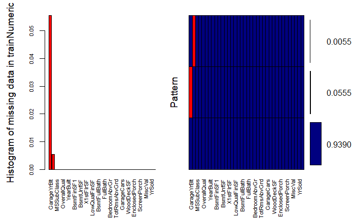

```r
library(VIM)
aggr_plot <- aggr(trainNumeric, col=c('navyblue','red'), numbers=TRUE, sortVars=TRUE, labels=names(trainNumeric), cex.axis=.7, gap=3, ylab=c("Histogram of missing data in trainNumeric","Pattern"))
```

```
not enough horizontal space to display frequencies
```

```
 Variables sorted by number of missings:
```

| Variable | Count |
| --- | --- |
| GarageType | 0.0554794521 |
| GarageFinish | 0.0554794521 |
| GarageQual | 0.0554794521 |
| GarageCond | 0.0554794521 |
| BsmtExposure | 0.0260273973 |
| BsmtFinType2 | 0.0260273973 |
| BsmtQual | 0.0253424658 |
| BsmtCond | 0.0253424658 |
| BsmtFinType1 | 0.0253424658 |
| MasVnrType | 0.0054794521 |

[output cut: 28 more lines]

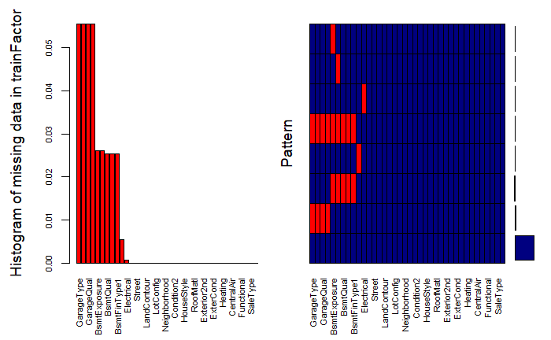

```r
aggr_plot <- aggr(trainFactor, col=c('navyblue','red'), numbers=TRUE, sortVars=TRUE, labels=names(trainFactor), cex.axis=.7, gap=3, ylab=c("Histogram of missing data in trainFactor","Pattern"))
```

# Now that we know what the missing values are, we will use mice package to impute the missing fields. for this pmm method which is predictive mean matching will be used, we will generate 5 imputed subsets

```r
require(mice)
imputer <- mice(trainNumeric,m=5,maxit=50,meth='pmm')
```

```
 * Please inspect the loggedEvents
```

```
Number of logged events: 1000
```

```r
summary(imputer)
```

```
Class: mids
Number of multiple imputations:  5
Imputation methods:
   MSSubClass       LotArea   OverallQual   OverallCond     YearBuilt  YearRemodAdd    MasVnrArea
           ""            ""            ""            ""            ""            ""         "pmm"
   BsmtFinSF1    BsmtFinSF2     BsmtUnfSF   TotalBsmtSF     X1stFlrSF     X2ndFlrSF  LowQualFinSF
           ""            ""            ""            ""            ""            ""            ""
    GrLivArea  BsmtFullBath  BsmtHalfBath      FullBath      HalfBath  BedroomAbvGr  KitchenAbvGr
           ""            ""            ""            ""            ""            ""            ""
 TotRmsAbvGrd    Fireplaces   GarageYrBlt    GarageCars    GarageArea    WoodDeckSF   OpenPorchSF
           ""            ""         "pmm"            ""            ""            ""            ""
EnclosedPorch    X3SsnPorch   ScreenPorch      PoolArea       MiscVal        MoSold        YrSold
           ""            ""            ""            ""            ""            ""            ""
    SalePrice
           ""
PredictorMatrix:
             MSSubClass LotArea OverallQual OverallCond YearBuilt YearRemodAdd MasVnrArea BsmtFinSF1
MSSubClass            0       1           1           1         1            1          1          1
LotArea               1       0           1           1         1            1          1          1
OverallQual           1       1           0           1         1            1          1          1
OverallCond           1       1           1           0         1            1          1          1
YearBuilt             1       1           1           1         0            1          1          1
YearRemodAdd          1       1           1           1         1            0          1          1
             BsmtFinSF2 BsmtUnfSF TotalBsmtSF X1stFlrSF X2ndFlrSF LowQualFinSF GrLivArea BsmtFullBath
MSSubClass            1         1           1         1         1            1         1            1
LotArea               1         1           1         1         1            1         1            1
OverallQual           1         1           1         1         1            1         1            1
OverallCond           1         1           1         1         1            1         1            1
YearBuilt             1         1           1         1         1            1         1            1
YearRemodAdd          1         1           1         1         1            1         1            1
             BsmtHalfBath FullBath HalfBath BedroomAbvGr KitchenAbvGr TotRmsAbvGrd Fireplaces
MSSubClass              1        1        1            1            1            1          1
LotArea                 1        1        1            1            1            1          1
OverallQual             1        1        1            1            1            1          1
OverallCond             1        1        1            1            1            1          1
YearBuilt               1        1        1            1            1            1          1
YearRemodAdd            1        1        1            1            1            1          1
             GarageYrBlt GarageCars GarageArea WoodDeckSF OpenPorchSF EnclosedPorch X3SsnPorch
MSSubClass             1          1          1          1           1             1          1
LotArea                1          1          1          1           1             1          1
OverallQual            1          1          1          1           1             1          1
OverallCond            1          1          1          1           1             1          1
YearBuilt              1          1          1          1           1             1          1
YearRemodAdd           1          1          1          1           1             1          1
             ScreenPorch PoolArea MiscVal MoSold YrSold SalePrice
MSSubClass             1        1       1      1      1         1
LotArea                1        1       1      1      1         1
OverallQual            1        1       1      1      1         1
OverallCond            1        1       1      1      1         1
YearBuilt              1        1       1      1      1         1
YearRemodAdd           1        1       1      1      1         1
Number of logged events:  1000
```

[output not shown]

```r
imputedtrainNumeric = complete(imputer, 1)
pMiss <- function(x){sum(is.na(x))/length(x)*100}
apply(imputedtrainNumeric,2,pMiss)
```

```
   MSSubClass       LotArea   OverallQual   OverallCond     YearBuilt  YearRemodAdd    MasVnrArea
            0             0             0             0             0             0             0
   BsmtFinSF1    BsmtFinSF2     BsmtUnfSF   TotalBsmtSF     X1stFlrSF     X2ndFlrSF  LowQualFinSF
            0             0             0             0             0             0             0
    GrLivArea  BsmtFullBath  BsmtHalfBath      FullBath      HalfBath  BedroomAbvGr  KitchenAbvGr
            0             0             0             0             0             0             0
 TotRmsAbvGrd    Fireplaces   GarageYrBlt    GarageCars    GarageArea    WoodDeckSF   OpenPorchSF
            0             0             0             0             0             0             0
EnclosedPorch    X3SsnPorch   ScreenPorch      PoolArea       MiscVal        MoSold        YrSold
            0             0             0             0             0             0             0
    SalePrice
            0
```

## Using polyreg to impute multi class categorical variable. we have reduced the number of iteration and number of multiple imputations to 2. since there are many features wuth missing data and having multiple iteration will render the results in slow manner

```r
require(mice)
imputerF <- mice(trainFactor,m=2,maxit=2,meth='polyreg')
```

```
Number of logged events: 44
```

```r
summary(imputerF)
```

```
Class: mids
Number of multiple imputations:  2
Imputation methods:
     MSZoning        Street      LotShape   LandContour     Utilities     LotConfig     LandSlope
           ""            ""            ""            ""            ""            ""            ""
 Neighborhood    Condition1    Condition2      BldgType    HouseStyle     RoofStyle      RoofMatl
           ""            ""            ""            ""            ""            ""            ""
  Exterior1st   Exterior2nd    MasVnrType     ExterQual     ExterCond    Foundation      BsmtQual
           ""            ""     "polyreg"            ""            ""            ""     "polyreg"
     BsmtCond  BsmtExposure  BsmtFinType1  BsmtFinType2       Heating     HeatingQC    CentralAir
    "polyreg"     "polyreg"     "polyreg"     "polyreg"            ""            ""            ""
   Electrical   KitchenQual    Functional    GarageType  GarageFinish    GarageQual    GarageCond
    "polyreg"            ""            ""     "polyreg"     "polyreg"     "polyreg"     "polyreg"
   PavedDrive      SaleType SaleCondition
           ""            ""            ""
PredictorMatrix:
            MSZoning Street LotShape LandContour Utilities LotConfig LandSlope Neighborhood Condition1
MSZoning           0      1        1           1         1         1         1            1          1
Street             1      0        1           1         1         1         1            1          1
LotShape           1      1        0           1         1         1         1            1          1
LandContour        1      1        1           0         1         1         1            1          1
Utilities          1      1        1           1         0         1         1            1          1
LotConfig          1      1        1           1         1         0         1            1          1
            Condition2 BldgType HouseStyle RoofStyle RoofMatl Exterior1st Exterior2nd MasVnrType
MSZoning             1        1          1         1        1           1           1          1
Street               1        1          1         1        1           1           1          1
LotShape             1        1          1         1        1           1           1          1
LandContour          1        1          1         1        1           1           1          1
Utilities            1        1          1         1        1           1           1          1
LotConfig            1        1          1         1        1           1           1          1
            ExterQual ExterCond Foundation BsmtQual BsmtCond BsmtExposure BsmtFinType1 BsmtFinType2
MSZoning            1         1          1        1        1            1            1            1
Street              1         1          1        1        1            1            1            1
LotShape            1         1          1        1        1            1            1            1
LandContour         1         1          1        1        1            1            1            1
Utilities           1         1          1        1        1            1            1            1
LotConfig           1         1          1        1        1            1            1            1
            Heating HeatingQC CentralAir Electrical KitchenQual Functional GarageType GarageFinish
MSZoning          1         1          1          1           1          1          1            1
Street            1         1          1          1           1          1          1            1
LotShape          1         1          1          1           1          1          1            1
LandContour       1         1          1          1           1          1          1            1
Utilities         1         1          1          1           1          1          1            1
LotConfig         1         1          1          1           1          1          1            1
            GarageQual GarageCond PavedDrive SaleType SaleCondition
MSZoning             1          1          1        1             1
Street               1          1          1        1             1
LotShape             1          1          1        1             1
LandContour          1          1          1        1             1
Utilities            1          1          1        1             1
LotConfig            1          1          1        1             1
Number of logged events:  44
```

|  | it | im | dep | meth | out |
| --- | --- | --- | --- | --- | --- |
| 1 | 1 | 1 | MasVnrType | polyreg | Exterior2ndCBlock |
| 2 | 1 | 1 | BsmtQual | polyreg | Exterior1stAsphShn, Exterior1stCBlock, FoundationSlab, HeatingGasA, HeatingWall |
| 3 | 1 | 1 | BsmtCond | polyreg | Exterior1stAsphShn, Exterior2ndCBlock, FoundationSlab, HeatingGasA, HeatingWall |
| 4 | 1 | 1 | BsmtExposure | polyreg | Exterior1stAsphShn, Exterior2ndCBlock, FoundationSlab, HeatingGasA, HeatingWall |
| 5 | 1 | 1 | BsmtFinType1 | polyreg | Exterior1stAsphShn, Exterior1stCBlock, FoundationSlab, HeatingGasW, HeatingWall |
| 6 | 1 | 1 | BsmtFinType2 | polyreg | Exterior1stAsphShn, Exterior1stCBlock, FoundationSlab, HeatingGasW, HeatingWall |

```r
imputedtrainFactor = complete(imputerF, 1)
pMiss <- function(x){sum(is.na(x))/length(x)*100}
apply(imputedtrainFactor,2,pMiss)
```

```
     MSZoning        Street      LotShape   LandContour     Utilities     LotConfig     LandSlope
            0             0             0             0             0             0             0
 Neighborhood    Condition1    Condition2      BldgType    HouseStyle     RoofStyle      RoofMatl
            0             0             0             0             0             0             0
  Exterior1st   Exterior2nd    MasVnrType     ExterQual     ExterCond    Foundation      BsmtQual
            0             0             0             0             0             0             0
     BsmtCond  BsmtExposure  BsmtFinType1  BsmtFinType2       Heating     HeatingQC    CentralAir
            0             0             0             0             0             0             0
   Electrical   KitchenQual    Functional    GarageType  GarageFinish    GarageQual    GarageCond
            0             0             0             0             0             0             0
   PavedDrive      SaleType SaleCondition
            0             0             0
```

# One hot encinding using fastDummies is done to convert categorical variable into numeric

**Also Removing all the actual columns since they have now been converted to dummy variable

```r
dummyimputedtrainFactor <- fastDummies::dummy_cols(imputedtrainFactor, remove_first_dummy = TRUE)
#results <- fastDummies::dummy_cols(fastDummies_example, remove_first_dummy = TRUE)
print(paste('dimension of imputedtrainFactor = ' ,dim(imputedtrainFactor)))
```

```
[1] "dimension of imputedtrainFactor =  1460" "dimension of imputedtrainFactor =  38"
```

```r
print(paste('dimension of dummyimputedtrainFactor = ' ,dim(dummyimputedtrainFactor)))
```

```
[1] "dimension of dummyimputedtrainFactor =  1460" "dimension of dummyimputedtrainFactor =  234"
```

```r
for (name in names(imputedtrainFactor)){

  dummyimputedtrainFactor[name] = NULL
}
print(paste('dim of dummyimputedtrainFactor = ' ,dim(dummyimputedtrainFactor)))
```

```
[1] "dim of dummyimputedtrainFactor =  1460" "dim of dummyimputedtrainFactor =  196"
```

# Removing all the near zero variance predictor. The variables that remains nearly constant through out will not help predict anything

```r
library(caret)
dim(dummyimputedtrainFactor) # dimension of dataset
```

```
[1] 1460  196
```

```r
nzv <- nearZeroVar(dummyimputedtrainFactor[,1:ncol(dummyimputedtrainFactor)], uniqueCut=10) # identify columns that are "near zero"
d_filtered <- dummyimputedtrainFactor[,1:ncol(dummyimputedtrainFactor)][, -nzv]            # remove those columns from your dataset
dim(d_filtered)
```

```
[1] 1460   55
```

```r
dim(imputedtrainNumeric) # dimension of dataset
```

```
[1] 1460   36
```

```r
nzv1 <- nearZeroVar(imputedtrainNumeric[,1:ncol(imputedtrainNumeric)], uniqueCut=10) # identify columns that are "near zero"
d_filtered_numeric <- imputedtrainNumeric[,1:ncol(imputedtrainNumeric)][, -nzv1]            # remove those columns from your dataset
dim(d_filtered_numeric)
```

```
[1] 1460   28
```

```r
setdiff(names(imputedtrainNumeric), names(d_filtered_numeric))
```

```
[1] "BsmtFinSF2"    "LowQualFinSF"  "KitchenAbvGr"  "EnclosedPorch" "X3SsnPorch"    "ScreenPorch"
[7] "PoolArea"      "MiscVal"
```

```r
table(imputedtrainNumeric$BsmtFinSF2)
```

```
   0   28   32   35   40   41   64   68   80   81   93   96  105  106  108  110  117  119  121  123
1293    1    1    1    1    2    2    1    1    1    2    2    1    1    1    1    2    1    1    1
 125  127  128  132  139  144  147  149  150  163  165  168  169  173  174  175  177  180  181  182
   1    1    1    1    1    1    2    1    1    1    1    1    1    1    1    1    1    5    1    2
 184  193  202  208  210  211  215  219  228  230  232  239  240  258  264  273  276  279  287  290
   1    1    1    1    1    1    1    1    1    1    1    1    1    1    1    1    1    2    2    2
 294  306  311  324  334  336  344  345  352  354  362  374  375  377  380  391  396  400  411  420
   2    1    1    1    1    1    1    1    1    1    1    3    1    1    1    2    1    1    1    1
 435  438  441  465  466  468  469  472  479  480  486  491  492  495  499  500  506  531  532  539
   1    1    1    1    1    2    2    1    1    2    1    1    1    1    1    1    1    1    1    2
 544  546  547  551  557  580  600  606  608  612  620  627  630  634  645  661  668  670  682  690
   1    1    1    2    1    1    1    1    1    1    1    1    1    1    1    1    1    1    1    1
 692  712  713  723  764  768  791  820  823  841  869  872  906  972 1029 1031 1057 1061 1063 1080
   1    2    1    1    1    1    1    1    1    1    1    1    1    1    1    1    1    1    1    1
1085 1120 1127 1474
   1    1    1    1
```

## Removing the variables that have correlation between them that is greater than 0.85. This is done so as to avoid the problem of VIF

```r
# calculate correlation matrix using Pearson's correlation formula
descrCor <-  cor(d_filtered[,1:ncol(d_filtered)])                           # correlation matrix
highCorr <- sum(abs(descrCor[upper.tri(descrCor)]) > .85) # number of Xs having a corr > some value
summary(descrCor[upper.tri(descrCor)])  # summarize the correlations
```

```
     Min.   1st Qu.    Median      Mean   3rd Qu.      Max.
-0.529969 -0.076141 -0.009985  0.009500  0.075468  0.986819
```

```r
highlyCorDescr <- findCorrelation(descrCor, cutoff = 0.85)
filteredDescr <- d_filtered[,1:ncol(d_filtered)][,-highlyCorDescr] # remove those specific columns from your dataset
descrCor2 <- cor(filteredDescr)                  # calculate a new correlation matrix
summary(descrCor2[upper.tri(descrCor2)])
```

```
     Min.   1st Qu.    Median      Mean   3rd Qu.      Max.
-0.529969 -0.070859 -0.009189  0.008843  0.074272  0.755085
```

```r
descrCorNum <-  cor(d_filtered_numeric[,1:(ncol(d_filtered_numeric)-1)])                           # correlation matrix
highCorrNum <- sum(abs(descrCorNum[upper.tri(descrCorNum)]) > .85) # number of Xs having a corr > some value
summary(descrCorNum[upper.tri(descrCorNum)])  # summarize the correlations
```

```
     Min.   1st Qu.    Median      Mean   3rd Qu.      Max.
-0.495252 -0.004201  0.119690  0.152090  0.270253  0.882475
```

```r
highlyCorDescrNum <- findCorrelation(descrCorNum, cutoff = 0.85)
filteredDescrNumeric <- d_filtered_numeric[,1:ncol(d_filtered_numeric)][,-highlyCorDescrNum] # remove those specific columns from your dataset
descrCor2Numeric <- cor(filteredDescrNumeric)                  # calculate a new correlation matrix
summary(descrCor2Numeric[upper.tri(descrCor2Numeric)])
```

```
     Min.   1st Qu.    Median      Mean   3rd Qu.      Max.
-0.495252 -0.004201  0.123122  0.158179  0.283047  0.825489
```

# The next step includes seeing if there is some linear combinations of features that is present in the model

```r
library(caret)
# create a column of 1s. This will help identify all the right linear combos
filteredDescr <- cbind(rep(1, nrow(filteredDescr)), filteredDescr[2:ncol(filteredDescr)])
names(filteredDescr)[1] <- "ones"
# identify the columns that are linear combos
comboInfo <- findLinearCombos(filteredDescr)
comboInfo
```

```
$`linearCombos`
list()

$`remove`
NULL
```

```r
drv <- JDBC(driverClass="org.postgresql.Driver"
            ,classPath="C:\Users\conne\Documents\MSBAIM 2018\Fall 2018\MGMT-57100-002 Data Mining\Tools - R, SQL\SQL")
```

```
Error: '\U' used without hex digits in character string starting ""C:\U"
```

# This step is for normalizing the variables

we are also dropping Exterior1st_Wd Sdng since it is having some problem with the header Here we dont need to normalize the factors that are one hot encoded

```r
# Step 1) figures out the means, standard deviations, other parameters, etc. to
# transform each variable
preProcValues <- preProcess(filteredDescrNumeric[,1:(ncol(filteredDescrNumeric)-1)], method = c("center","scale"))
# Step 2) the predict() function actually does the transformation using the
# parameters identified in the previous step. Weird that it uses predict() to do
# this, but it does!
dNums <- predict(preProcValues, filteredDescrNumeric)
dNums[,'ones'] = NULL
filteredDescr[,'ones'] = NULL
filteredDescr$`Exterior1st_Wd Sdng`= NULL
```

# combining both the numeric and the one hot encoded factor variable

```r
modeldata = cbind(dNums,filteredDescr)
```

# Splitting the data into train set and validation set

```r
trainSet <- sample(nrow(modeldata), 0.75*nrow(modeldata), replace = FALSE)
TrainingSet <- modeldata[trainSet,]
ValidationSet <- modeldata[-trainSet,]
#summary(TrainingSet)
#summary(ValidationSet)
```

# We will try using RandomForest for the purpose of prediction

```r
require(randomForest)
#names(TrainingSet)['Exterior1st_Wd Sdng'] <- "Exterior1st_Wd_Sdng"
# Create a Random Forest model with default parameters
model <- randomForest(SalePrice ~ ., data =TrainingSet, ntree = 500, mtry = 10  ,importance = TRUE)
model
```

```
Call:
 randomForest(formula = SalePrice ~ ., data = TrainingSet, ntree = 500,      mtry = 10, importance = TRUE)
               Type of random forest: regression
                     Number of trees: 500
No. of variables tried at each split: 10

          Mean of squared residuals: 883491292
                    % Var explained: 85.95
```

# Viewing how the Error rate in model reduced as the number of trees increased

Also checking the number of trees that gives the minimum error

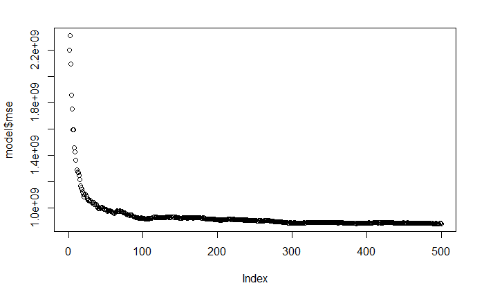

```r
plot(model$mse)
```

```r
which.min(model$mse)
```

```
[1] 496
```

## Finding the prediction corresponding to the input

and the rmse root mean squared error value

```r
pred_randomForest <- predict(model, ValidationSet)
head(pred_randomForest)
```

```
       7       14       22       29       33       36
290762.7 227472.2 129830.2 188458.2 210188.7 309272.3
```

```r
sqrt(model$mse[which.min(model$mse)])
```

```
[1] 29708.72
```

# https://uc-r.github.io/random_forests

# Finding the rmsle error that used as the evaluation parameter on Kaggle

```r
require(Metrics)
rmsle(ValidationSet$SalePrice, pred_randomForest)
```

```
[1] 0.1436178
```

```r
library(xgboost)
x_train = TrainingSet[,-grep('SalePrice', colnames(TrainingSet))]
y_train = TrainingSet$SalePrice
dtrain <- data.matrix(x_train)
#dtrain = data.matrix(TrainingSet)
label = TrainingSet$SalePrice
xgb <- xgboost(data = data.matrix(x_train),
 label = y_train,
 eta = 0.1,
 max_depth = 5,
 nround=250,
 subsample = 0.5,
 colsample_bytree = 0.5,
 seed = 1,
 eval_metric = "rmse",
 objective = "reg:linear",
 nthread = 3
)
dim(dtrain)
```

```
[1] 1095   75
```

```r
# predict values in test set
x_test = ValidationSet[,-grep('SalePrice', colnames(ValidationSet))]
y_test = ValidationSet$SalePrice
#validat = xgb.DMatrix(as.matrix(sapply(valida, as.numeric)), label=SalePrice)
y_pred <- predict(xgb, data.matrix(x_test))
```

```r
require(Metrics)
rmsle(y_test, y_pred)
```

```
[1] 0.1212689
```

[figure not shown]

```r
rmsle(y_test, pred_randomForestSteps)
```

```
[1] 0.06474689
```

```r
rf <- train(SalePrice ~ .,
            data = TrainingSet,
            method = "rf",
            importance=T,    # we add this in or it varImp cannot be computed
            trControl = ctrl,
            tuneLength = 10,
            metric = "RMSE"
)
rf
```

```
Random Forest

1095 samples
  74 predictor

No pre-processing
Resampling: Cross-Validated (3 fold)
Summary of sample sizes: 731, 729, 730
Resampling results across tuning parameters:

  mtry  RMSE      Rsquared   MAE
   2    37640.90  0.8204370  21948.04
  10    33134.27  0.8368812  18209.22
  18    32939.28  0.8350504  18013.87
  26    33228.12  0.8311521  18193.60
  34    32886.89  0.8328387  18135.44
  42    33545.22  0.8255197  18437.79
  50    33672.40  0.8237014  18596.24
  58    33694.98  0.8235908  18733.80
  66    33888.89  0.8213788  18790.99
  74    34004.28  0.8207898  18871.67

RMSE was used to select the optimal model using the smallest value.
The final value used for the model was mtry = 34.
```

```r
mb_pred1 <- predict(mb, TrainingSet)
```

```
Error in UseMethod("predict") :
  no applicable method for 'predict' applied to an object of class "regsubsets"
```

```r
columnNames = names(test)
#print(columnNames)
#Initializing the separate dataframe to NULL so that in case of any error they don't keep previous records
testNumeric = NULL
testFactor = NULL
#Iterating over column names and putting it into appropriate basket
for (name in columnNames){
  print(is.null(testFactor))
  if('factor' == toString(class(test[[name]]))){
    if(is.null(testFactor)){
     testFactor = test[name]
    }
    testFactor[name] = test[[name]]
  } else{
    if(is.null(testNumeric)){
     testNumeric = test[name]
    }
    testNumeric[name] = test[[name]]
  }
}
```

```
[1] TRUE
[1] TRUE
[1] TRUE
[1] TRUE
[1] FALSE
[1] FALSE
[1] FALSE
[1] FALSE
[1] FALSE
[1] FALSE
[1] FALSE
[1] FALSE
[1] FALSE
[1] FALSE
[1] FALSE
```

[output cut: 66 more lines]

```r
dummyimputedtestFactor <- fastDummies::dummy_cols(testFactor, remove_first_dummy = FALSE)
colnames(testNumeric)
```

```
 [1] "X"             "Id"            "MSSubClass"    "LotFrontage"   "LotArea"       "OverallQual"
 [7] "OverallCond"   "YearBuilt"     "YearRemodAdd"  "MasVnrArea"    "BsmtFinSF1"    "BsmtFinSF2"
[13] "BsmtUnfSF"     "TotalBsmtSF"   "X1stFlrSF"     "X2ndFlrSF"     "LowQualFinSF"  "GrLivArea"
[19] "BsmtFullBath"  "BsmtHalfBath"  "FullBath"      "HalfBath"      "BedroomAbvGr"  "KitchenAbvGr"
[25] "TotRmsAbvGrd"  "Fireplaces"    "GarageYrBlt"   "GarageCars"    "GarageArea"    "WoodDeckSF"
[31] "OpenPorchSF"   "EnclosedPorch" "X3SsnPorch"    "ScreenPorch"   "PoolArea"      "MiscVal"
[37] "MoSold"        "YrSold"
```

```r
testFactorfilt <- dummyimputedtestFactor[,colnames(filteredDescr)]
testNumericfilt <- testNumeric[setdiff(colnames(dNums),"SalePrice")]
#names(dummyimputedtestFactor)
pMiss <- function(x){sum(is.na(x))/length(x)*100}
apply(testFactorfilt,2,pMiss)
```

```
         LotShape_IR1      LotConfig_Corner     LotConfig_CulDSac  Neighborhood_Somerst
                    0                     0                     0                     0
  Neighborhood_NWAmes  Neighborhood_OldTown   Neighborhood_Sawyer  Neighborhood_NridgHt
                    0                     0                     0                     0
   Neighborhood_NAmes  Neighborhood_Edwards  Neighborhood_Gilbert      Condition1_Feedr
                    0                     0                     0                     0
      BldgType_TwnhsE     HouseStyle_1Story     HouseStyle_1.5Fin         RoofStyle_Hip
                    0                     0                     0                     0
  Exterior1st_Plywood   Exterior2nd_MetalSd   Exterior2nd_HdBoard   Exterior2nd_Plywood
                    0                     0                     0                     0
      MasVnrType_None      MasVnrType_Stone          ExterQual_TA          ExterCond_Gd
                    0                     0                     0                     0
    Foundation_CBlock     Foundation_BrkTil           BsmtQual_TA           BsmtQual_Ex
                    0                     0                     0                     0
      BsmtExposure_Gd       BsmtExposure_Mn       BsmtExposure_Av      BsmtFinType1_ALQ
                    0                     0                     0                     0
     BsmtFinType1_Unf      BsmtFinType1_Rec      BsmtFinType1_BLQ      BsmtFinType1_LwQ
                    0                     0                     0                     0
         HeatingQC_Gd          HeatingQC_TA          CentralAir_N      Electrical_FuseA
                    0                     0                     0                     0
       KitchenQual_TA        KitchenQual_Ex     GarageType_Detchd    GarageType_BuiltIn
                    0                     0                     0                     0
     GarageFinish_Unf      GarageFinish_Fin          PavedDrive_N SaleCondition_Abnorml
                    0                     0                     0                     0
SaleCondition_Partial
                    0
```

```r
pMiss <- function(x){sum(is.na(x))/length(x)*100}
apply(testNumericfilt,2,pMiss)
```

```
  MSSubClass      LotArea  OverallQual  OverallCond    YearBuilt YearRemodAdd   MasVnrArea   BsmtFinSF1
    0.000000     0.000000     0.000000     0.000000     0.000000     0.000000     1.028101     0.000000
   BsmtUnfSF  TotalBsmtSF    X1stFlrSF    X2ndFlrSF    GrLivArea BsmtFullBath BsmtHalfBath     FullBath
    0.000000     0.000000     0.000000     0.000000     0.000000     0.000000     0.000000     0.000000
    HalfBath BedroomAbvGr TotRmsAbvGrd   Fireplaces  GarageYrBlt   GarageArea   WoodDeckSF  OpenPorchSF
    0.000000     0.000000     0.000000     0.000000     5.346127     0.000000     0.000000     0.000000
      MoSold       YrSold
    0.000000     0.000000
```

```r
require(mice)
imputertestNum <- mice(testNumericfilt,m=1,maxit=1,meth='cart')
#summary(imputerF)
imputedtestNumeric = complete(imputertestNum, 1)
apply(imputedtestNumeric,2,pMiss)
```

```
  MSSubClass      LotArea  OverallQual  OverallCond    YearBuilt YearRemodAdd   MasVnrArea   BsmtFinSF1
           0            0            0            0            0            0            0            0
   BsmtUnfSF  TotalBsmtSF    X1stFlrSF    X2ndFlrSF    GrLivArea BsmtFullBath BsmtHalfBath     FullBath
           0            0            0            0            0            0            0            0
    HalfBath BedroomAbvGr TotRmsAbvGrd   Fireplaces  GarageYrBlt   GarageArea   WoodDeckSF  OpenPorchSF
           0            0            0            0            0            0            0            0
      MoSold       YrSold
           0            0
```

```r
preProcValuesF <- preProcess(imputedtestNumeric[,1:(ncol(imputedtestNumeric))], method = c("center","scale"))
# Step 2) the predict() function actually does the transformation using the
# parameters identified in the previous step. Weird that it uses predict() to do
# this, but it does!
dNumsF <- predict(preProcValuesF, imputedtestNumeric)
finalTestData = cbind(dNumsF,testFactorfilt)
```

```r
pred_randomForest_test<- predict(model, finalTestData)
head(pred_randomForest)
```

[output not shown]

```r
sqrt(model$mse[which.min(model$mse)])
```

[output not shown]

```r
all[-'SalePrice']
```

```
Error in -"SalePrice" : invalid argument to unary operator
```

```r
colnames(submit)[1] <- "Id"
colnames(submit)[2] <- "SalePrice"
colnames(submit)
```

```
[1] "Id"        "SalePrice"
```